# Tossing a coin: Preferences for random allocation in triage decisions

# Versions

R version 4.4.1 (2024-06-14) Platform: aarch64-apple-darwin20 Running under: macOS Sonoma 14.6

Matrix products: default BLAS: /System/Library/Frameworks/Accelerate.framework/Versions/A/Frameworks/vecLib.framework/Versions/A/libBLAS.dylib LAPACK: /Library/Frameworks/R.framework/Versions/4.4-arm64/Resources/lib/libRlapack.dylib; LAPACK version 3.12.0

locale: [1] en_US.UTF-8/en_US.UTF-8/en_US.UTF-8/C/en_US.UTF-8/en_US.UTF-8

time zone: Europe/Berlin tzcode source: internal

attached base packages: [1] stats graphics grDevices utils datasets methods base

other attached packages: [1] janitor_2.2.0 lubridate_1.9.3 forcats_1.0.0 stringr_1.5.1 dplyr_1.1.4 purrr_1.0.2 readr_2.1.5  
[8] tidyr_1.3.1 tibble_3.2.1 ggplot2_3.5.1 tidyverse_2.0.0 ggthemes_5.1.0 bife_0.7.2 survival_3.6-4  
[15] margins_0.3.28 ordinal_2023.12-4.1 magrittr_2.0.3 lmerTest_3.1-3 lme4_1.1-35.5 Matrix_1.7-0

loaded via a namespace (and not attached): [1] gtable_0.3.6 prediction_0.3.18 xfun_0.48 bslib_0.8.0 lattice_0.22-6 tzdb_0.4.0 numDeriv_2016.8-1.1 [8] vctrs_0.6.5 tools_4.4.1 generics_0.1.3 fansi_1.0.6 ucminf_1.2.2 pkgconfig_2.0.3 data.table_1.16.2  
[15] lifecycle_1.0.4 compiler_4.4.1 farver_2.1.2 munsell_0.5.1 snakecase_0.11.1 sass_0.4.9 htmltools_0.5.8.1  
[22] yaml_2.3.10 Formula_1.2-5 pillar_1.9.0 nloptr_2.1.1 jquerylib_0.1.4 MASS_7.3-60.2 cachem_1.1.0  
[29] boot_1.3-30 nlme_3.1-164 tidyselect_1.2.1 digest_0.6.37 stringi_1.8.4 labeling_0.4.3 splines_4.4.1  
[36] fastmap_1.2.0 grid_4.4.1 colorspace_2.1-1 cli_3.6.3 utf8_1.2.4 withr_3.0.2 scales_1.3.0  
[43] timechange_0.3.0 rmarkdown_2.28 hms_1.1.3 evaluate_1.0.1 knitr_1.48 rlang_1.1.4 Rcpp_1.0.13  
[50] glue_1.8.0 jsonlite_1.8.9 rstudioapi_0.17.1 minqa_1.2.8 R6_2.5.1

# Packages

[output not shown]

# Figures

## Figure 1

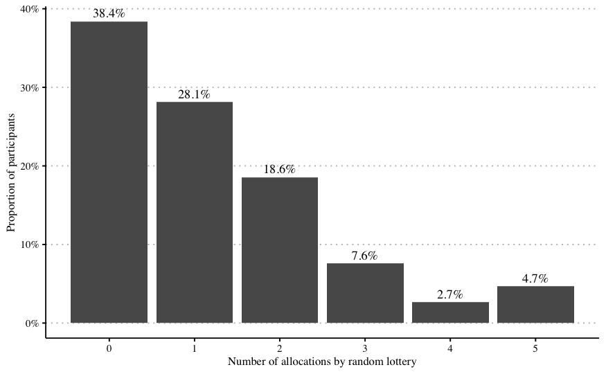

## Figure 2

```
G3;boundary (singular) fit: see help('isSingular')
g
```

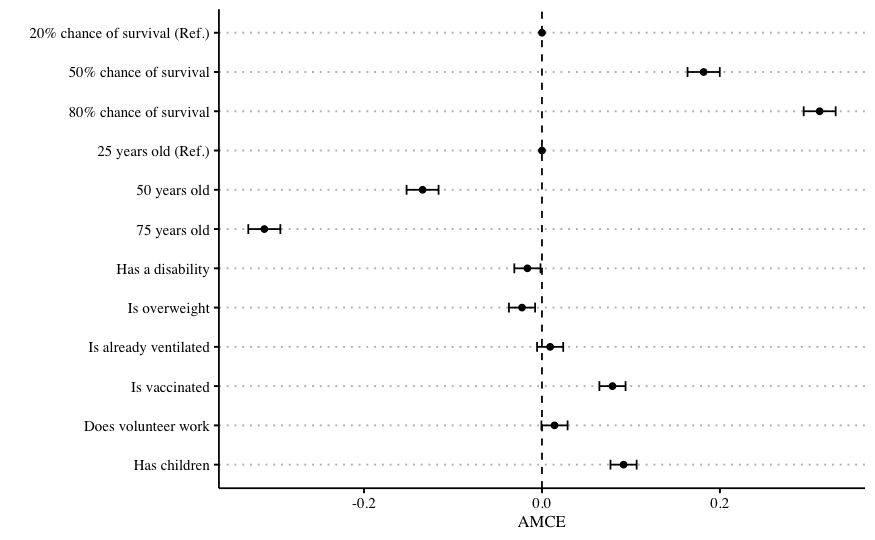

### Regression table

```
G3;boundary (singular) fit: see help('isSingular')
g
```

```
Linear mixed model fit by REML. t-tests use Satterthwaite's method ['lmerModLmerTest']
Formula: vig_choice ~ vig_weight + vig_age + vig_chance_of_survival_with_ventilation +
    vig_ventilation_status + vig_children + vig_disability +
    vig_volunteer_work + vig_vaccination_status + (1 | id)
   Data: .

REML criterion at convergence: 19550.8

Scaled residuals:
     Min       1Q   Median       3Q      Max
-1.97241 -0.92462  0.04195  0.90736  2.05631

Random effects:
 Groups   Name        Variance Std.Dev.
 id       (Intercept) 0.0000   0.000
 Residual             0.2125   0.461
Number of obs: 15106, groups:  id, 1905

Fixed effects:
                                                                Estimate Std. Error
(Intercept)                                                    4.029e-01  1.245e-02
vig_weightOverweight                                          -2.242e-02  7.505e-03
vig_age50 years old                                           -1.342e-01  9.170e-03
vig_age75 years old                                           -3.121e-01  9.190e-03
vig_chance_of_survival_with_ventilation50% chance of survival  1.817e-01  9.242e-03
vig_chance_of_survival_with_ventilation80% chance of survival  3.121e-01  9.173e-03
vig_ventilation_statusIs already ventilated                    9.194e-03  7.503e-03
vig_childrenHas children                                       9.172e-02  7.504e-03
vig_disabilityHas a disability                                -1.636e-02  7.503e-03
vig_volunteer_workDoes volunteer work                          1.410e-02  7.504e-03
vig_vaccination_statusIs vaccinated                            7.925e-02  7.504e-03
                                                                      df t value Pr(>|t|)
(Intercept)                                                    1.510e+04  32.351  < 2e-16
vig_weightOverweight                                           1.510e+04  -2.987  0.00282
vig_age50 years old                                            1.510e+04 -14.633  < 2e-16
vig_age75 years old                                            1.510e+04 -33.956  < 2e-16
vig_chance_of_survival_with_ventilation50% chance of survival  1.510e+04  19.665  < 2e-16
vig_chance_of_survival_with_ventilation80% chance of survival  1.510e+04  34.028  < 2e-16
vig_ventilation_statusIs already ventilated                    1.510e+04   1.225  0.22048
vig_childrenHas children                                       1.510e+04  12.222  < 2e-16
```

[output cut: 17 more lines]

```

Correlation of Fixed Effects:
            (Intr) vg_wgO v_50yo v_75yo v_____5cos v_____8cos v__Iav vg_cHc vg_Had v__Dvw
vg_wghtOvrw -0.300
vg_g50yrsol -0.377  0.010
vg_g75yrsol -0.374 -0.010  0.496
v_____50cos -0.377  0.003  0.003  0.008
v_____80cos -0.372 -0.010  0.008  0.019  0.505
vg_vntl_Iav -0.300  0.010  0.003  0.009  0.003     -0.008
vg_chldrnHc -0.295 -0.002  0.013  0.011 -0.015     -0.009      0.003
vg_dsbltHad -0.293 -0.003 -0.002 -0.011  0.003     -0.004     -0.002 -0.009
vg_vlnt_Dvw -0.301 -0.007  0.006  0.014  0.010      0.009     -0.009 -0.007 -0.005
vg_vccnt_Iv -0.305  0.010 -0.004 -0.008  0.003     -0.009     -0.004 -0.007  0.006  0.003
optimizer (nloptwrap) convergence code: 0 (OK)
boundary (singular) fit: see help('isSingular')
```

## Figure 3

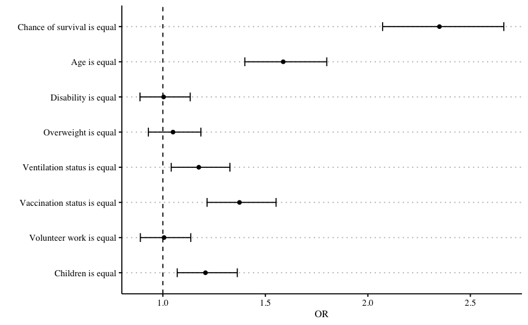

### Regression table

```
Call:
coxph(formula = Surv(rep(1, 9990L), random) ~ same_survival +
    same_age + same_disability + same_weight + same_ventilation +
    same_vaccination + same_volunteer + same_children + strata(id),
    method = "exact")

  n= 9990, number of events= 2437

                     coef exp(coef) se(coef)      z Pr(>|z|)
same_survival    0.854023  2.349078 0.064008 13.342  < 2e-16 ***
same_age         0.461926  1.587128 0.064077  7.209 5.64e-13 ***
same_disability  0.003633  1.003639 0.062132  0.058  0.95338
same_weight      0.048374  1.049563 0.062131  0.779  0.43623
same_ventilation 0.161513  1.175288 0.062010  2.605  0.00920 **
same_vaccination 0.317573  1.373790 0.062305  5.097 3.45e-07 ***
same_volunteer   0.005771  1.005788 0.062256  0.093  0.92614
same_children    0.188820  1.207824 0.061762  3.057  0.00223 **
---
Signif. codes:  0 ‘***’ 0.001 ‘**’ 0.01 ‘*’ 0.05 ‘.’ 0.1 ‘ ’ 1

                 exp(coef) exp(-coef) lower .95 upper .95
same_survival        2.349     0.4257    2.0721     2.663
same_age             1.587     0.6301    1.3998     1.800
same_disability      1.004     0.9964    0.8886     1.134
same_weight          1.050     0.9528    0.9292     1.185
same_ventilation     1.175     0.8509    1.0408     1.327
same_vaccination     1.374     0.7279    1.2159     1.552
same_volunteer       1.006     0.9942    0.8903     1.136
same_children        1.208     0.8279    1.0701     1.363

Concordance= 0.627  (se = 0.012 )
Likelihood ratio test= 278  on 8 df,   p=<2e-16
Wald test            = 259.8  on 8 df,   p=<2e-16
Score (logrank) test = 275.8  on 8 df,   p=<2e-16
```

## Figure 4

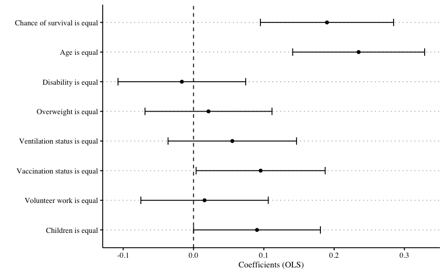

### Regression table

```
Linear mixed model fit by REML. t-tests use Satterthwaite's method ['lmerModLmerTest']
Formula: fairness_random ~ same_survival + same_age + same_vaccination +
    same_volunteer + same_disability + same_children + same_ventilation +
    same_weight + (1 | id)

REML criterion at convergence: 7796.5

Scaled residuals:
    Min      1Q  Median      3Q     Max
-3.7367 -0.4433  0.0385  0.5155  2.4214

Random effects:
 Groups   Name        Variance Std.Dev.
 id       (Intercept) 0.6378   0.7986
 Residual             0.9484   0.9739
Number of obs: 2437, groups:  id, 1231

Fixed effects:
                   Estimate Std. Error         df t value Pr(>|t|)
(Intercept)         3.88348    0.07161 2418.96648  54.230  < 2e-16 ***
same_survival       0.18986    0.04832 2304.81588   3.929 8.77e-05 ***
same_age            0.23487    0.04788 2183.34022   4.906 9.99e-07 ***
same_vaccination    0.09549    0.04685 2181.94690   2.038   0.0416 *
same_volunteer      0.01568    0.04625 2154.19449   0.339   0.7346
same_disability    -0.01660    0.04635 2152.90465  -0.358   0.7203
same_children       0.09030    0.04604 2128.86302   1.961   0.0500 *
same_ventilation    0.05519    0.04663 2175.06908   1.183   0.2368
same_weight         0.02131    0.04606 2133.40544   0.463   0.6437
---
Signif. codes:  0 ‘***’ 0.001 ‘**’ 0.01 ‘*’ 0.05 ‘.’ 0.1 ‘ ’ 1

Correlation of Fixed Effects:
            (Intr) sm_srv same_g sm_vcc sm_vln sm_dsb sm_chl sm_vnt
same_survvl -0.274
same_age    -0.238 -0.034
same_vccntn -0.348 -0.022  0.004
same_volntr -0.335  0.001  0.012 -0.002
same_dsblty -0.312 -0.015 -0.031 -0.002 -0.011
same_chldrn -0.323  0.003 -0.035 -0.022 -0.001  0.031
same_vntltn -0.336 -0.052  0.015 -0.030 -0.013  0.042  0.018
same_weight -0.320  0.011 -0.018  0.035  0.040 -0.048 -0.033  0.004
```

## Figure A4

[figure not shown]

### Regression table (CLMM)

```
Cumulative Link Mixed Model fitted with the Laplace approximation

formula: fairness_random ~ same_survival + same_age + same_vaccination +
    same_volunteer + same_disability + same_children + same_ventilation +
    same_weight + (1 | id)
data:    .
```

| link | threshold | nobs | logLik | AIC | niter | max.grad | cond.H |
| --- | --- | --- | --- | --- | --- | --- | --- |
| logit | flexible | 2437 | -3653.65 | 7335.30 | 2245(15549) | 1.16e-03 | 1.0e+02 |

```
Random effects:
 Groups Name        Variance Std.Dev.
 id     (Intercept) 2.888    1.699
Number of groups:  id 1231

Coefficients:
                 Estimate Std. Error z value Pr(>|z|)
same_survival     0.35059    0.09664   3.628 0.000286 ***
same_age          0.47644    0.09612   4.957 7.17e-07 ***
same_vaccination  0.21445    0.09318   2.302 0.021363 *
same_volunteer    0.02895    0.09185   0.315 0.752570
same_disability   0.01536    0.09226   0.166 0.867779
same_children     0.20257    0.09186   2.205 0.027437 *
same_ventilation  0.10407    0.09276   1.122 0.261917
same_weight       0.02816    0.09189   0.306 0.759247
---
Signif. codes:  0 ‘***’ 0.001 ‘**’ 0.01 ‘*’ 0.05 ‘.’ 0.1 ‘ ’ 1

Threshold coefficients:
    Estimate Std. Error z value
1|2  -3.8926     0.1971 -19.745
2|3  -2.5370     0.1651 -15.367
3|4  -1.0719     0.1505  -7.124
4|5   1.2037     0.1498   8.037
5|6   2.9426     0.1678  17.538
```

# Appendix

## Marginal means

```
G3;boundary (singular) fit: see help('isSingular')
g
```

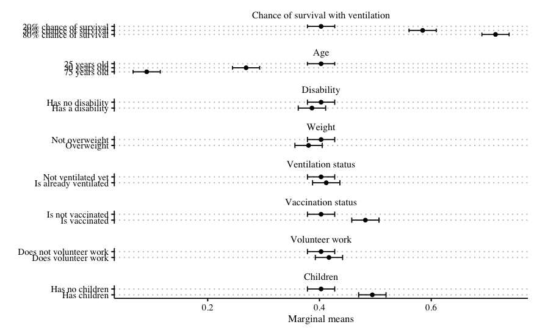